# devcontainer

国里愛彦

## 環境構築は簡単にやりたい！

- 生成AIの活用を考えるとVSCodeが便利なんだけど、正直環境構築はめんどくさい。
- ワンクリックで環境が準備できて欲しい

## Devcontainerとは(Gemini曰く)

- Devcontainer（デブコンテナ）は、Dockerコンテナを開発環境として利用するための仕組みです。Visual Studio Code（VS Code）の拡張機能として提供されており、プロジェクトごとに隔離された一貫性のある開発環境を簡単に構築・共有できます。
- これにより、「自分のPCでは動くのに、他の人のPCでは動かない」といった環境差異の問題を解消し、開発チームの生産性を向上させます。

## Devcontainerの仕組み(Gemini曰く)

- Devcontainerは、プロジェクトのルートディレクトリに配置された `.devcontainer` というフォルダ内の設定ファイルに基づいて動作します。

主な設定ファイルは以下の2つです。

- `devcontainer.json`: Devcontainerのメインとなる設定ファイルです。使用するDockerイメージやDockerfileの場所、コンテナ内で自動的にインストールするVS Codeの拡張機能、コンテナ作成後に実行するコマンドなどを定義します。
- `Dockerfile`: 開発環境のベースとなるDockerイメージを定義するファイルです。OSの指定や、必要なソフトウェア、ライブラリのインストール手順などを記述します。

## devcontainer.jsonの例

- Dockerfileを指定して、コンテナの準備をしてからインストールする必要があるtinytexとcmdstanはコンテナ準備後に自動インストールする。
- “vscode”の”extensions”で拡張機能を色々と追加

```json
{
    "name": "${localWorkspaceFolderBasename}",
    "build": {
        "dockerfile": "Dockerfile"
    },
    "postCreateCommand": "Rscript -e 'tinytex::install_tinytex(); tinytex::tlmgr_install(\"haranoaji\"); cmdstanr::install_cmdstan(cores = 2)'",
    "customizations": {
        "vscode": {
            "extensions": [
                "quarto.quarto",
                "TianyiShi.rmarkdown",
                "yzhang.markdown-all-in-one",
                "mechatroner.rainbow-csv",
                "GrapeCity.gc-excelviewer",
                "REditorSupport.r",
                "REditorSupport.r-syntax",
                "Tailscale.vscode-tailscale",
                "janisdd.vscode-edit-csv"
            ]
        }
    }
}
```

## Dockerfileの例

- ビルドが面倒なので、イメージをDocker Hubにアップして使っている(VScodeでRを使う際に便利なツールはすでに入っている)。
- 追加でRパッケージをインストールする場合は、”install_r.r”にインストールコマンドを追加する。

```
FROM ykunisato/dev-con-r

ENV TZ=Asia/Tokyo
# Rのパッケージのインストール
COPY install_r.r install_r.r
RUN ["r", "install_r.r"]
```

## devcontainer template for CCP Lab

- CCP Labとか書いているけど、私しか使ってないdevcontainerテンプレート
- Macユーザーにつき、Arm64版のみ。Dockerfileを少し書き換えて、ローカルでビルドすればAmd64とかでも動くはず。

https://github.com/ykunisato/devcontainer-template-ccp-lab

## Tailscaleでより便利に

- 柏原さんに教えてもらったTailscale(VPN)とdevconで、出先や自宅のノートPCから研究室のWSにアクセスして作業できる(設定は個別連絡を)

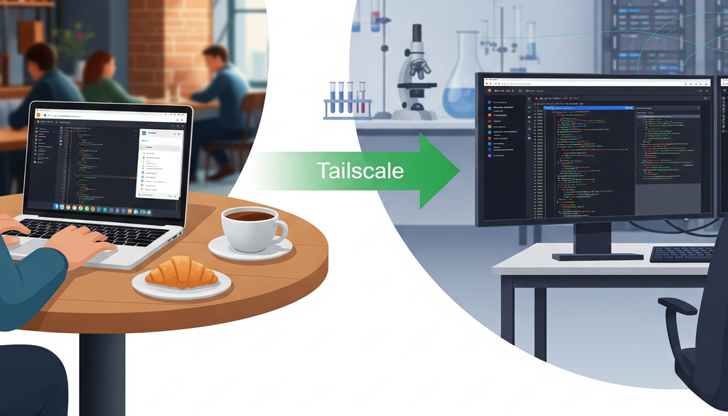

## R・devcontainerの有用情報源

- Rocker Projectのウェブサイトの説明

https://rocker-project.org/use/editor.html#visual-studio-code-dev-containers

- サンプル

https://github.com/rocker-org/devcontainer-try-r